# `sbi`

We'll explore SBI techniques such as neural posterior estimation and neural likelihood estimation using the `sbi` python package: https://sbi.readthedocs.io/en/latest/. We'll go through the sample inference examples as the SBI with variational inference demo.

```python
import numpy as np
import matplotlib.pyplot as plt
import corner
```

To install the `sbi` package use

```
python -m pip install sbi
```

in your conda environment. Beware of some `torch` and `jupyter` version requirements that may conflict.

```python
import sbi
import torch
```

```python
np.random.seed(10)
```

# Example 0

Let's return to the example from a few weeks ago

> We point our telescope to observe the light from a single star with true flux $F_{\rm true}$, which remains constant with time. We will ignore any systematic errors. We perform $N$ measurements with our telescope, where the $i^{\rm th}$ measurement report an observed flux $F_i$ with uncertainty/error $e_i$.

Lets generate a synthetic observation

```python
F_true = 1000
F_obs = np.random.poisson(lam=F_true)
```

```python
# simulator of the data generation process
def simulation(F_true):
    return np.random.poisson(lam=F_true)
```

For our prior, lets use a simple Gaussian $$p(\theta) = \mathcal{N}(1002, 4)$$ This would hypothetically be measurement from a prior experiment

```python
def sample_prior():
    # sample prior
    return 1002. + 4. * np.random.normal()
```

Let's sample $p(\theta, \mathcal{D})$

```python
Nsample = 10000

samples = np.zeros((Nsample, 2))
for i in range(Nsample):
    theta_p = sample_prior()
    data_p = simulation(theta_p)
    samples[i,:] = np.array([theta_p, data_p])
samples = torch.tensor(samples, dtype=torch.float32)
```

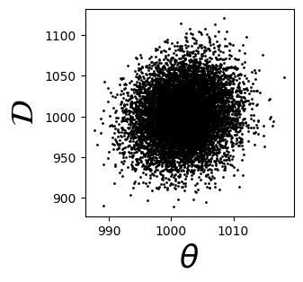

```python
# plot p(theta, D)
fig = plt.figure(figsize=(3,3))
sub = fig.add_subplot(111)
sub.scatter(samples[:,0].numpy(), samples[:,1].numpy(), s=1, c='k')
sub.set_xlabel(r'$\theta$', fontsize=25)
sub.set_ylabel('$\mathcal{D}$', fontsize=25); plt.show()
```

Now lets use

## neural posterior estimation

to directly estimate the posterior with a neural density estimator

```python
from sbi.inference import NPE
```

`sbi` package has a convenient `NPE` inference object. You can specify the neural density estimator. Here we'll initially use MADE

```python
made = NPE(density_estimator='made')
```

Now we can provide the `NPE` the simulations, or samples $\{(\theta', \mathcal{D}')\}$

```python
_ = made.append_simulations(samples[:,0][:,None], samples[:,1][:,None])
```

Then, train the NPE

```python
npe_made = made.train()
```

```
 Neural network successfully converged after 24 epochs.
```

After training the NPE, we can performance inference as follows

```python
posterior_made = made.build_posterior()
print(posterior_made)
```

```
Posterior p(θ|x) of type DirectPosterior. It samples the posterior network and rejects samples that
            lie outside of the prior bounds.
```

```python
q_samples0 = posterior_made.sample((10000,), x=F_obs)
```

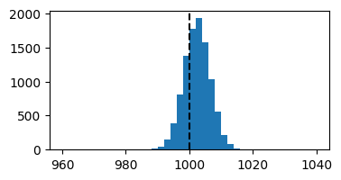

```python
plt.figure(figsize=(4,2))
plt.hist(q_samples0, range=(960, 1040), bins=40)
plt.axvline(F_true, color='k', linestyle='--'); plt.show()
```

Since the `sbi` package makes it very convenient to try different neural density estimators, now lets try with MAF.

```python
maf = NPE(density_estimator='maf')

# append (theta, D) from the simulations
_ = maf.append_simulations(torch.tensor(samples[:,0][:,None], dtype=torch.float32),
                           torch.tensor(samples[:,1][:,None], dtype=torch.float32))
# train NPE.
npe_maf = maf.train()
```

```
 Neural network successfully converged after 63 epochs.
```

Then the inference

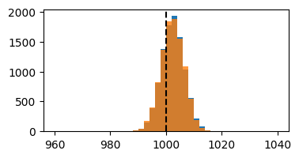

```python
posterior_maf = maf.build_posterior()
q_samples1 = posterior_made.sample((10000,), x=F_obs)

plt.figure(figsize=(4,2))
plt.hist(q_samples0, range=(960, 1040), bins=40)
plt.hist(q_samples1, range=(960, 1040), bins=40, alpha=0.8)
plt.axvline(F_true, color='k', linestyle='--'); plt.show()
```

# Example 1

Now lets fits a line to some data with Gaussian priors (same as the SBI + VI demo)

```python
a_true, b_true = 0, 1.75
x = np.array([1, 1.5, 2, 2.5])
y = np.array([1.87640523, 2.59001572, 3.4978738 , 4.47408932])
yerr = 0.1
```

```
<ErrorbarContainer object of 3 artists>
```

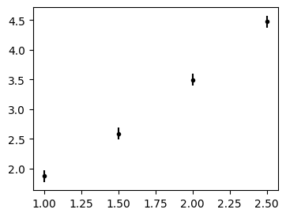

```python
plt.figure(figsize=(4,3))
plt.errorbar(x, y, yerr=yerr, fmt='.k')
```

```python
def simulation(theta):
    a, b = theta
    noise = yerr * np.random.normal(size=len(x))
    return a + b * x + noise

def sample_prior():
    # sample a and b from uniform prior
    _a = -0.5 + np.random.normal()
    _b = 5 + 3*np.random.normal()
    return [_a, _b]
```

same as above, sample $(\theta', \mathcal{D}') \sim p(\theta, \mathcal{D})$

```python
Nsample = 500000

samples = np.zeros((Nsample, 6))
for i in range(Nsample):
    theta_p = sample_prior()
    data_p = simulation(theta_p)
    samples[i,:] = np.concatenate([theta_p, data_p])
samples = torch.tensor(samples, dtype=torch.float32)
```

Now train the NPE

```python
maf = NPE(density_estimator='maf')

# append (theta, D) from the simulations
_ = maf.append_simulations(samples[:,:2], samples[:,2:])
# train NPE.
npe_maf = maf.train()
```

```
 Neural network successfully converged after 42 epochs.
```

```python
posterior_maf = maf.build_posterior()
q_samples = posterior_maf.sample((10000,), x=torch.tensor(y, dtype=torch.float32))
```

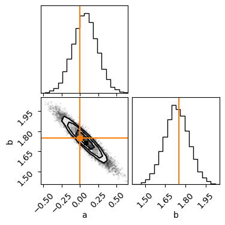

```python
fig = plt.figure(figsize=(4,4))
fig = corner.corner(q_samples.numpy(), labels=['a', 'b'], fig=fig)
corner.overplot_lines(fig, [a_true, b_true], color="C1")
corner.overplot_points(fig, np.array([a_true, b_true])[None], marker="s", color="C1")
```

# Example 1.b

Now what happens if we change the prior to the uniform priors. Recall that this was problematic for SBI with VI due to the limited flexibility of our surrogate

```python
def simulation(theta):
    a, b = theta
    noise = yerr * np.random.normal(size=len(x))
    return a + b * x + noise

def sample_prior():
    # sample a and b from uniform prior
    _a = -0.5 + np.random.uniform()
    _b = 10*np.random.uniform()
    return [_a, _b]

Nsample = 500000

samples = np.zeros((Nsample, 6))
for i in range(Nsample):
    theta_p = sample_prior()
    data_p = simulation(theta_p)
    samples[i,:] = np.concatenate([theta_p, data_p])
samples = torch.tensor(samples, dtype=torch.float32)
```

```python
maf = NPE(density_estimator='maf')

# append (theta, D) from the simulations
_ = maf.append_simulations(samples[:,:2], samples[:,2:])
# train NPE.
npe_maf = maf.train()
```

```
 Neural network successfully converged after 86 epochs.
```

```python
posterior_maf = maf.build_posterior()
q_samples = posterior_maf.sample((10000,), x=torch.tensor(y, dtype=torch.float32))
```

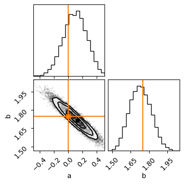

```python
fig = plt.figure(figsize=(4,4))
fig = corner.corner(q_samples.numpy(), labels=['a', 'b'], fig=fig)
corner.overplot_lines(fig, [a_true, b_true], color="C1")
corner.overplot_points(fig, np.array([a_true, b_true])[None], marker="s", color="C1")
```

# unit summary

- with NDEs we can bypass ABC for more direct SBI: **neural posterior estimation**
- neural likelihood estimation, neural ratio estimation, sequential neural posterior estimation
- neural posterior estimation using the `sbi` python package --- SBI in ~5 lines